# Agent based economics z użyciem RNetLogo. Przykład Zero Intelligence Trading.

Karol Ciulkin

29 czerwca 2016

Niniejszy dokument stanowi przykład analizy modelu wieloagentowego. Aby samodzielnie wygenerować taki plik konieczne jest zainstalowanie NetLogo (najlepiej w wersji 5.3.1) oraz (w R) pakietów `RNetLogo`, `ggplot2` oraz `data.table`, a następnie wykonanie skryptu `code/main.R` będącego elementem niniejszego projektu. Zawiera on część generującą dane oraz wykonuje plik `.Rmd`. Można przyspieszyć jego działanie zmniejszając wartość zmiennej `ilePowtorzen` oraz różnicę w dwuelementowym wektorze `zakresHeatmap`.

```r
library(RNetLogo)
library(ggplot2)
library(data.table)
```

Pierwszy z pakietów służy do komunikacji pomiędzy R a NetLogo. Używa przy tym Javy i pakietu `rJava`. Aktualność tychże zostanie prawdopodobnie zweryfikowana przy instalacji powyższego pakietu, ale warto o tym pamiętać.

## Opis modelu

Użyty w niniejszym raporcie model pochodzi z https://github.com/memcbride/ZITrading. Jest to klasyczny model Gode i Sunder (1993) napisany w języku NetLogo.

Celem Gode i Sunder (1993) była weryfikacja hipotezy, że do efektywnego działania rynków konieczne jest klasyczne dla nauk ekonomicznych założenie racjonalności podmiotów działających na rynku. W tym celu napisali oni model symulacyjny, w którym dwa rodzaje agentów (sprzedający i kupujący) handlują na rynku, na którym ceny są ustalane z użyciem mechanizmu podwójnej aukcji (ang. *double action*). Następnie przeprowadzili eksperymenty obliczeniowe (*computational experiments*) oraz eksperyment ekonomiczny, w którym brali udział studenci.

W pierwszym eksperymencie w rynkach uczestniczyli agenci “głupi” (*zero intelligence*), którzy zgłaszali losowe ceny. Rynki takie nie osiągały wysokiej efektywności.

W drugim na rynku działali agenci o ograniczonej racjonalności (*zero intelligence with constraints*). W ich przypadku cena, którą mieli zgłosić (generowana z użyciem tego samego procesu losowego co u “głupich” agentów) była przez nich zgłaszana zgłaszana tylko jeśli spełniała ich ograniczenie budżetowe.

Autorom udało się udowodnić, że do osiągnięcia satysfakcjonującej efektywności wystarczy jedynie ograniczona racjonalność agentów działających na rynku. Wyniki osiągane przez takich agentów były porównywalne z tymi, które osiągali uczestniczący w eksperymentach studenci, choć osiągane ceny charakteryzowały się większą wariancją. Publikacja wyników tego badania spowodowała wzrost zainteresowania naukowego projektowaniem mechanizmów rynkowych w celu ograniczenia występowania kryzysów.

## Analiza wpływu parametrów modelu na efektywność

Wynikiem symulacji z użyciem pakietu mogą być różne zestawy zmiennych. W niniejszym dokumencie skupię się na wyjaśnianiu efektywności. Gode i Sunder rozumieją ją jako stosunek wygenerowanej podaży do maksymalnej możliwej podaży przy danych krzywych (popytu i podaży). Ujemna efektywność oznacza zatem ujemną podaż. Nie wiem jak to możliwe, ale model akceptuje takie wyniki.

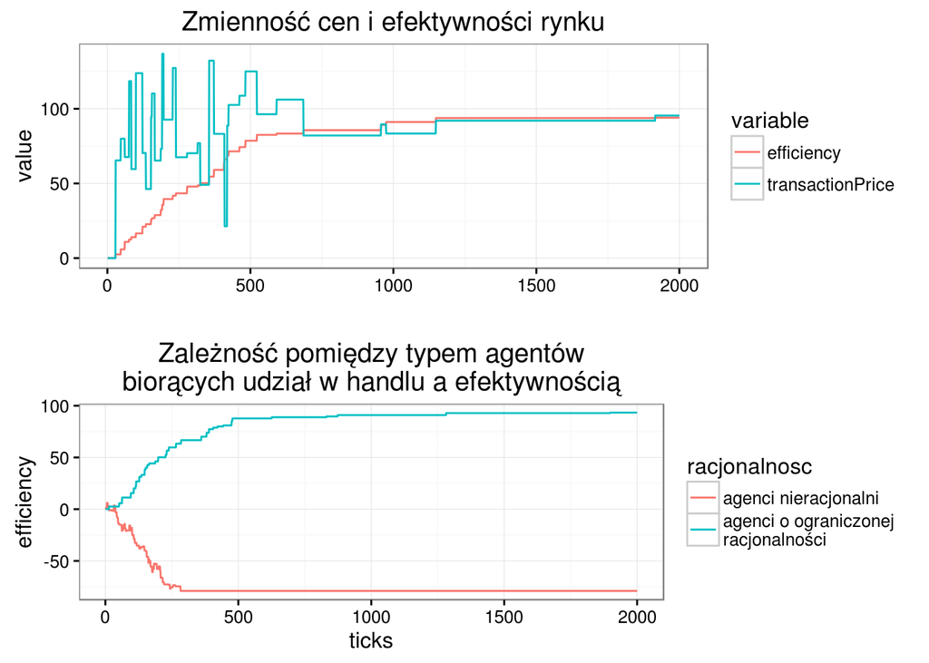

#### Kupujący vs sprzedający

Można porównywać wyniki symulacji w zależności od parametrów. Poniżej znajduje się heatmapa opisująca zależność pomiędzy efektywnością a liczbą kupujących i sprzedających agentów.

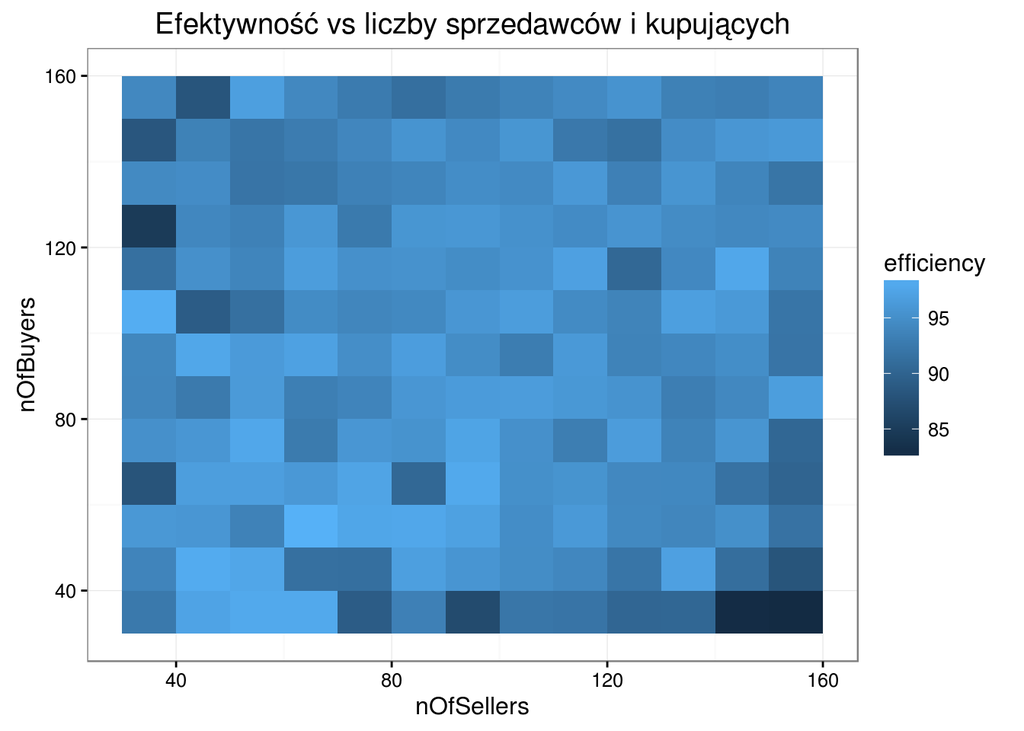

Jak widać, brak jest jednoznacznej, na przykład liniowej zależności. Da się natomiast zauważyć, że najniższe wartości są obserwowane przy 35 kupujących oraz 155 sprzedających. Można więc przyjrzeć się temu wycinkowi bliżej:

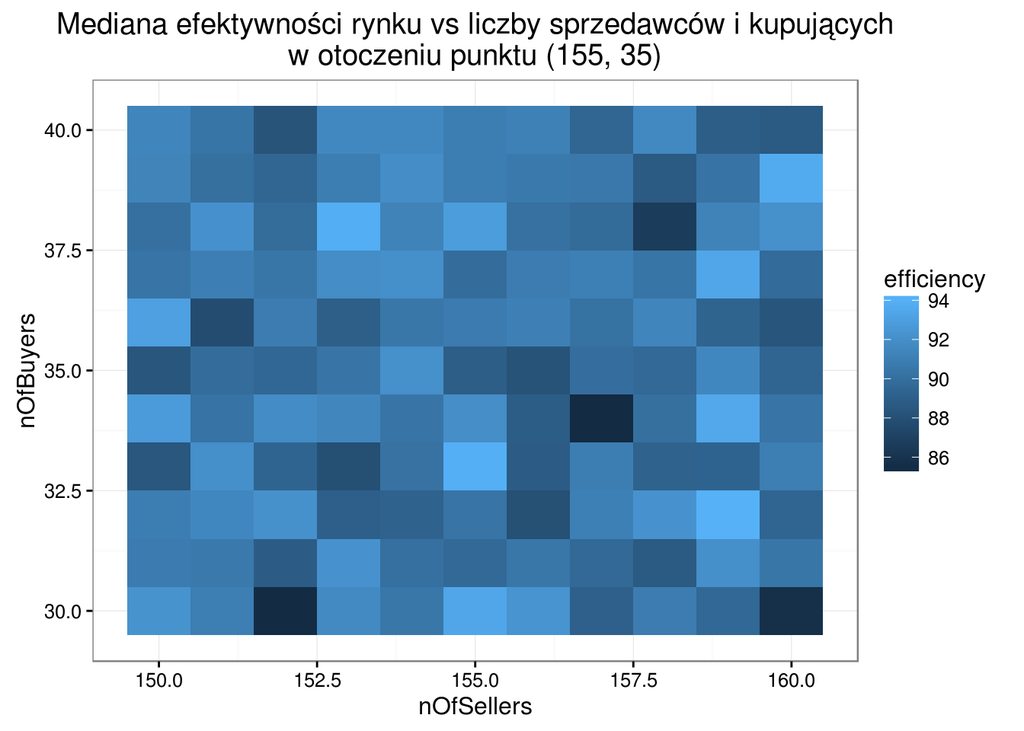

#### Liczba uczestników rynku

Ciekawy może być również wpływ liczby uczestników rynku na osiąganą efektywność. W celu zwizualizowania tej zależności przeprowadzono symulacje na coraz większym rynku, dzieląc uczestników na równe grupy. Dla każdego podziału wykonano po 5 iteracji oraz wybrano medianę efektywności. Wyniki można zobaczyć poniżej:

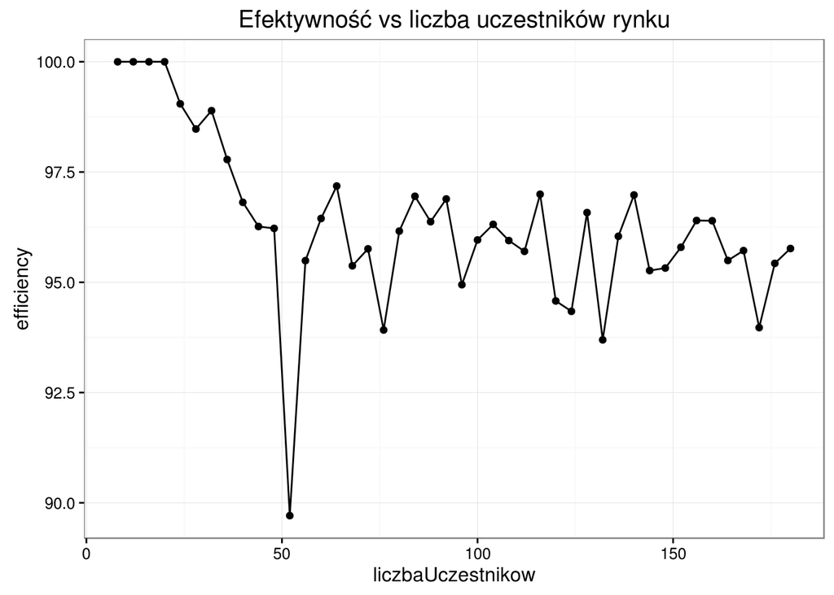

Maksimum wyniosło 100%, a minimum 89.71%. Poniżej znajduje się wykres pudełkowy efektywności dla 20 realizacji eksperymentu dla 52 uczestników.

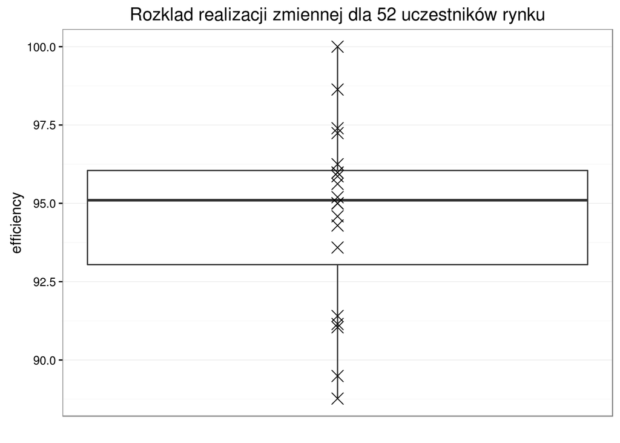

## Zakończenie

Niniejszy dokument stanowi przykład użycia pakietu `RNetLogo` w automatycznym generowaniu dokumentu z wykorzystaniem `RMarkdown`. Załączone funkcje (ścieżka `code/functions.R`), którymi opakowałem standardowe komendy `RNetLogo` działają jedynie razem z użytym w dokumencie modelem. Mimo to, przejrzenie ich powinno dać podstawową wiedzę o tym, w jaki sposób należy używać pakietu do komunikowania się z NetLogo poprzez R.

## Bibliografia

1. Gode, D. K., & Sunder, S. (1993). Allocative efficiency of markets with zero-intelligence traders: Market as a partial substitute for individual rationality. Journal of political economy, 119-137.
2. R Core Team (2016). R: A language and environment for statistical computing. R Foundation for Statistical Computing, Vienna, Austria. URL https://www.R-project.org/.
3. Thiele, J. C. (2014). R marries NetLogo: introduction to the RNetLogo package.
4. Wilensky, U. (1999). NetLogo. http://ccl.northwestern.edu/netlogo/. Center for Connected Learning and Computer-Based Modeling, Northwestern University, Evanston, IL.
5. https://github.com/memcbride/ZITrading